# Lab 5b: Mixture Models and Variance Stabilization

Bios 221: Modern Statistics for Modern Biology

10/9/2019

## Goal

In this lab we will learn the basics of mixture modeling. Mixtures models are strongly tied to both your previous lab on Clustering, but also your next lab on RNA-Seq analysis. Furthermore, we will learn about the Bootstrap and variance stabilizing transformations: You already used a variance stabilizing transformation in the clustering Lab, and heard about its application to RNA-Seq data in class yesterday. The Lab does not have an associated Quiz, however there are questions interspersed throughout to which we will post solutions.

## Load packages

```r
pkgs_needed = c("tidyverse", "ggplot2", "mixtools", "HistData",
                "bootstrap", "ggbeeswarm", "pasilla", "matrixStats", "DESeq2")
BiocManager::install(setdiff(pkgs_needed, installed.packages()))
library("tidyverse")
library("ggplot2")
library("mixtools")
library("HistData")
library("bootstrap")
library("ggbeeswarm")
library("pasilla")
library("matrixStats")
library("DESeq2")
```

## Introduction

In the lectures we saw that sequences could come from CpG islands or not and that the nucleotide patterns were different in each. Sometimes we can see the data as a simple mixture of a few components, we call these finite mixtures. Other mixtures can involve almost as many types as we have observations, these we call infinite mixtures.

We also saw a simple generative model with a Poisson distribution led us to make useful inferences in the detection of an Epitope. Unfortunately, a satisfactory fit to real data with such a simple model is often out of reach. However, simple models such as the normal or Poisson distributions can serve as building blocks for more realistic models using the mixing framework, which occurs naturally for flow cytometry data, biometric measurements, for RNA-seq, Chip-Seq, microbiome and many other types of data collected using modern biotechnology.

## Finite Mixtures

### Simple examples and computer experiments

Here is a first example of a mixture model with two equally important components. We decompose the generating process into steps:

1. Flip a fair coin
2. If it comes up heads, generate a random number from a normal with mean 1 and variance 0.25.
3. If it comes up tails, generate a random number from a normal with mean 3 and variance 0.25.

Let's produce a histogram by repeating these three steps 10,000 times.

```r
coinflips = (runif(10000) > 0.5)
table(coinflips)
```

```
## coinflips
## FALSE  TRUE
##  4943  5057
```

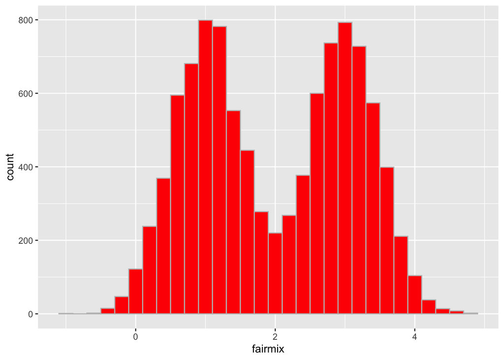

```r
sd1 = 0.5 ; sd2 = 0.5
mean1 = 1 ; mean2 = 3

fairmix = rnorm(length(coinflips),
                mean = ifelse(coinflips, mean1, mean2),
                sd   = ifelse(coinflips, sd1,   sd2))
fairdf = data.frame(fairmix)
ggplot(fairdf, aes(x = fairmix)) +
    geom_histogram(fill = "red", color = "grey", binwidth = 0.2)
```

**Question 1:** How many modes are there?

**Question 2:** Modify the code below to simulate one million coin flips and make a histogram with 500 bins.

```r
B = 1e+6
coinflips = (runif(B)>0.5)
fairmix = rnorm(length(coinflips),
                mean = ifelse(coinflips, mean1, mean2),
                sd   = ifelse(coinflips, sd1,   sd2))
fairdf = data.frame(fairmix)
# Make the plot below using bins = 500 instead of binwidth = 0.2 in geom_histogram()
```

What you should see is that with many observations and bins, the histogram is becoming similar to a smooth curve. This smooth limiting curve is called *the density function* of the random variable `fairmix`.

The density function for a normal ${\mathcal N}(\mu,\sigma)$ random variable can be written explicitly, we usually call it $\phi(x)=\frac{1}{\sigma \sqrt{2\pi}}e^{-\frac{1}{2}(\frac{x-\mu}{\sigma})^2}$.

Next we will proceed as follows:

1. For cases where the coinflip was one, make a histogram of `fairmix` values. Use a binwidth of 0.01, choose {y = ..density..} in the `ggplot()` {aes} mapping, meaning that the vertical axis is the density of counts (i.e. values such that the area of the histograms is 1).
2. Overlay the line corresponding to $\phi(z)$

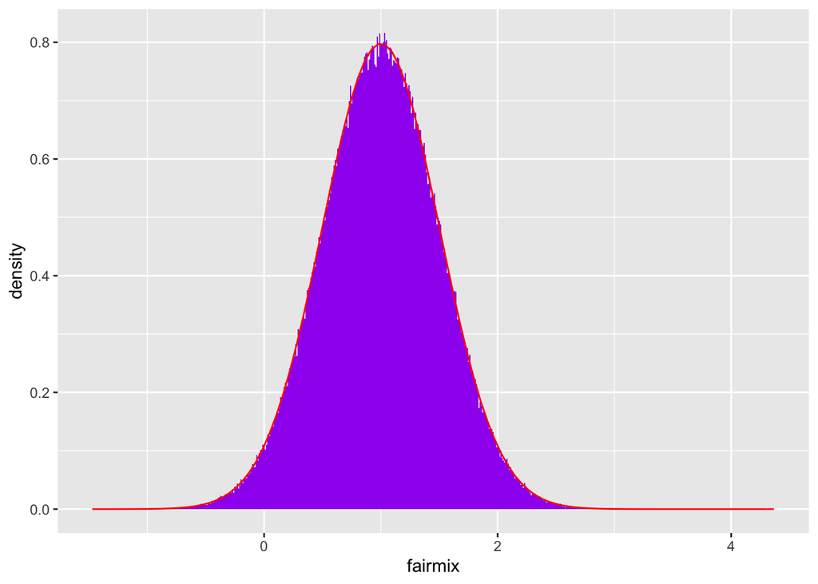

```r
faird = data.frame(fairdf,coinflips)
setone = faird %>% dplyr::filter(coinflips==1)
fnpoints = faird[sample(nrow(faird),1000),]
ggplot(setone, aes(x= fairmix)) +
   geom_histogram(aes(y = ..density..), fill = "purple", binwidth=0.01) +
   stat_function(fun = dnorm, data=fnpoints,
                       args = list(mean = mean1, sd = sd2),color="red")
```

In fact, we can write the mathematical formula for the density (the limiting curve that the histograms tend to look like) as a sum of the two densities.

$$\begin{equation}
f(x)=\frac{1}{2}\phi_1(x)+\frac{1}{2}\phi_2(x)
\label{eq:halfhalf}
\end{equation}$$

where $\phi_1$ is the density of the normal ${\mathcal N}(\mu_1=1,\sigma^2=0.25)$ and $\phi_2$ is the density of the normal ${\mathcal N}(\mu_2=3,\sigma^2=0.25)$. Hence by using the function `dnorm` we can produce theoretical density plots as below:

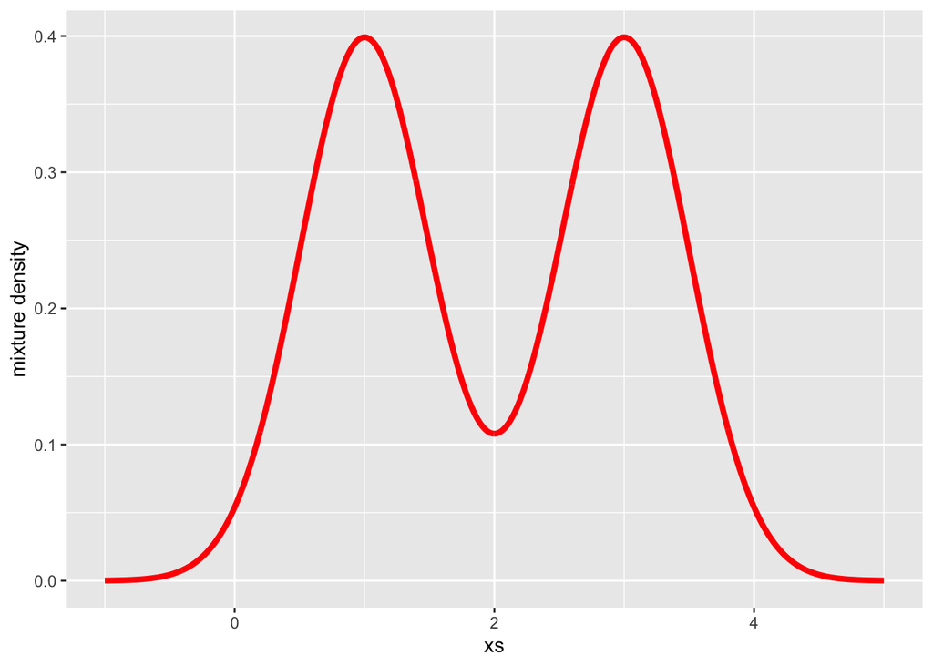

```r
xs = seq(-1, 5, length = 1000)
dens2 = 0.5 * dnorm(xs, mean=1, sd=0.5)+
        0.5 * dnorm(xs, mean=3, sd=0.5)
fairtheory=data.frame(xs,dens2)
ggplot(fairtheory)+ aes(x = xs, y = dens2) +
  geom_line(color = "red",size=1.5) + ylab("mixture density")
```

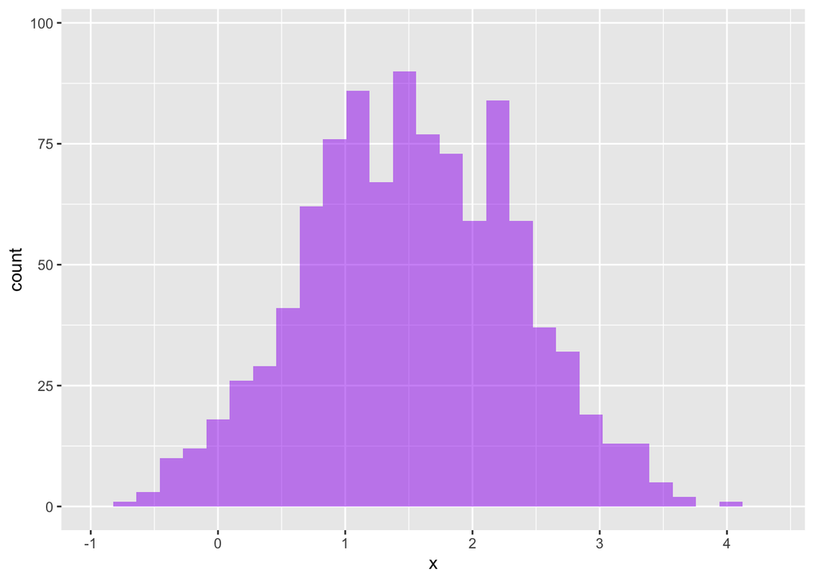

```r
set.seed(1233341)
sd1 = sd2 = sqrt(0.5)
mean1 = 1; mean2 = 2
coinflips = (runif(1000) > 0.5)

output = rnorm(length(coinflips),
               mean = ifelse(coinflips, mean1, mean2),
               sd   = ifelse(coinflips, sd1,   sd2))

ht = hist(output,nclass=30, plot=FALSE)
maxcount = max(ht$count)
mysterydata = data.frame(x = output, group = ifelse(coinflips, "A", "B"))
xmin = min(output); xmax = max(output)

ggplot(mysterydata, aes(x = x)) +
  geom_histogram(fill = "purple", alpha = 0.5, bins=30)+
  xlim(c(xmin,xmax))+ ylim(c(0, maxcount))
```

If we color in red the histogram that was generated from the *heads* coin flip and blue the one from *tails*, we can see the the two underlying distributions.

```r
head( mysterydata, 3)
```

```
##           x group
## 1 2.7530620     B
## 2 2.2659780     B
## 3 0.5606189     A
```

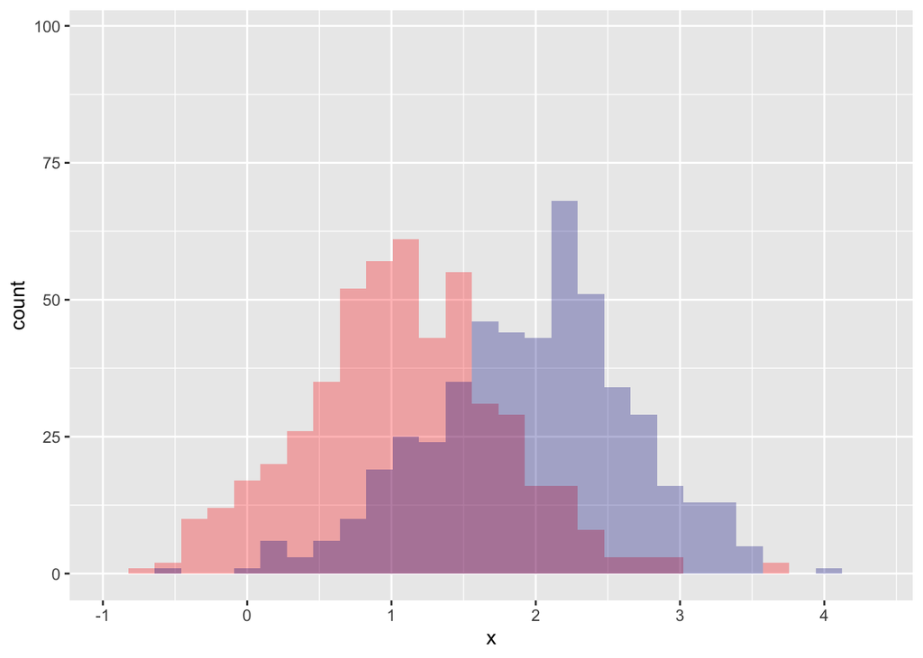

```r
ggplot(mysterydata, aes(x = x,group= group)) +
  geom_histogram(data = dplyr::filter(mysterydata, group == "A"),
                 fill = "red",  alpha = 0.3, bins = 30) +
  geom_histogram(data = dplyr::filter(mysterydata, group == "B"),
                 fill = "darkblue", alpha = 0.3, bins = 30) +
  xlim(c(xmin,xmax))+ ylim(c(0, maxcount))
```

The overlapping points are piled up on top of each other in the final histogram.

Here it is in an overlaid plot showing the three histograms: the two components and the mixture in orange.

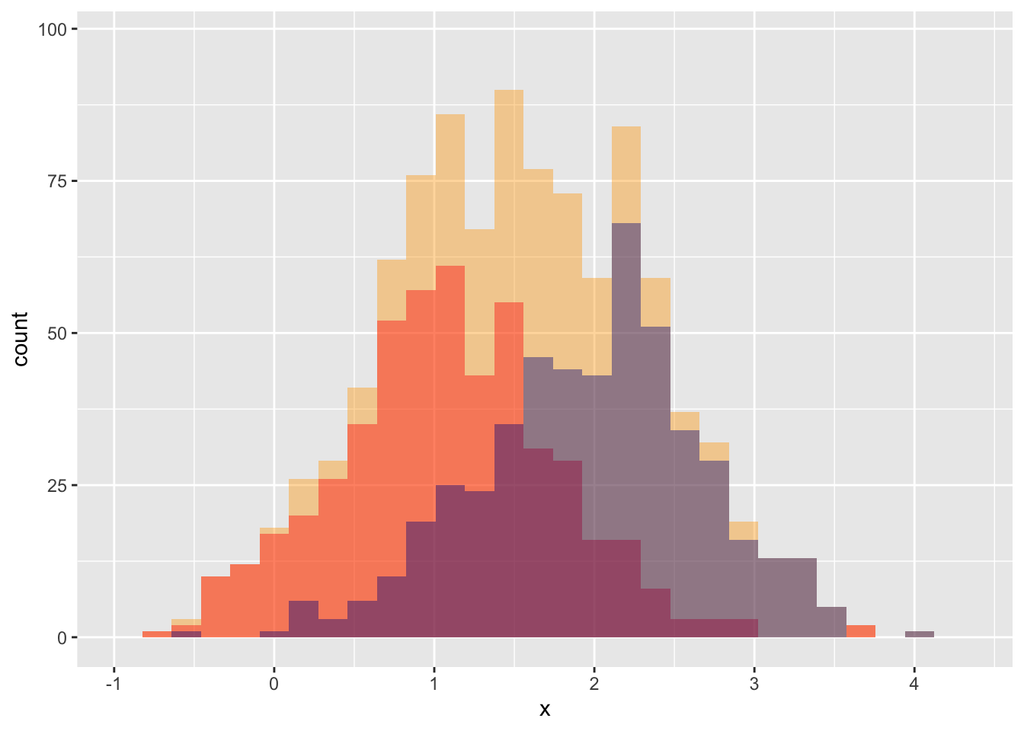

```r
ggplot(mysterydata, aes(x = x)) +
  geom_histogram(fill = "orange", alpha = 0.4, bins=30) +
  geom_histogram(data = dplyr::filter(mysterydata, group == "A"),
                 fill = "red",  alpha = 0.4 , bins=30) +
  geom_histogram(data = dplyr::filter(mysterydata, group == "B"),
                 fill = "darkblue", alpha = 0.4, bins=30) +
  xlim(c(xmin,xmax))+ ylim(c(0, maxcount))
```

Here we were able to color each of the components using the function `filter` from the `dplyr` package because we knew how we had generated the points, their provenance was either A or B depending on the original coinflip. In real data, this information is missing.

## Discovering the hidden class labels

In the case of simple parametric components, we use a method called the expectation-maximization (EM) algorithm to infer the value of the hidden groupings. The expectation-maximization algorithm is a popular iterative procedure that alternates between

- pretending we know the probability with which each observation belongs to a component and estimating the parameters of the components,
- and pretending we know the parameters of the component distributions and estimating the probability with which each observation belongs to the components.

### Mixture of normals

Suppose we have a mixture of two normals with mean parameters unknown and standard deviations $1$, $(\mu_1=?,\,\mu_2=?,\,\sigma_1=\sigma_2=1)$.

Here is an example of data generated according to this model, the labels are $u$.

```r
set.seed(198435)
mus = c(-0.5,1.5)
u = sample(2, 20, replace = TRUE)
y = rnorm(length(u), mean = mus[u])
duy = data.frame(u, y)
group_by(duy, u)[1:6, ]
```

```
## # A tibble: 6 x 2
## # Groups:   u [2]
##       u      y
##   <int>  <dbl>
## 1     2  1.91
## 2     1 -0.711
## 3     1 -1.18
## 4     2  1.75
## 5     2  2.74
## 6     2  2.37
```

If we would know the true labels, we could split the data into two independent pieces and estimate parameters for each piece independently:

```r
group_by(duy, u) %>% summarize(mean(y))
```

```
## # A tibble: 2 x 2
##       u `mean(y)`
##   <int>     <dbl>
## 1     1    -0.815
## 2     2     1.64
```

In reality we do not know the $u$ labels, nor do we know the mixture is balanced (i.e. $\alpha=\frac{1}{2}$). We have to start with an initial guesses for the labels and the parameters and go through several iterations of the algorithm, updating at each step our current best guess of the group labels and the parameters until we see no substantial improvement in our optimizations.

A somewhat more elaborate implementation of this algorithm has been implemented in the `mixtools` package:

```r
library("mixtools")
n1 = 100; n2 = 50
mu1 = -0.2; mu2 = 0.5
sigma1 = 0.5; sigma2 = 1

y = c(rnorm(n1, mu1, sd = sigma1), rnorm(n2, mu2, sigma2))
gm = normalmixEM(y, k = 2, lambda = c(0.5, 0.5),
                 mu = c(-0.02, 0.02), sigma = c(1, 1))
```

```
## number of iterations= 92
```

```r
gm$lambda
```

```
## [1] 0.5209328 0.4790672
```

```r
gm$mu
```

```
## [1] -0.10613598  0.01686444
```

```r
gm$sigma
```

```
## [1] 0.3215075 1.0110636
```

**Question 3**: a) Try to increase the samples size n1 and n2. What happens then? b) Why do you get different results every time you run this code? c) How can you make it produce always the same result?

## Bootstrap

In this section we consider the the differences in heights of 15 pairs (15 self hybridized and 15 crossed) of *Zea Mays* plants (data were generated by Darwin in a carefully designed paired experiment).

```r
library("HistData")
ZeaMays$diff
```

```
##  [1]  6.125 -8.375  1.000  2.000  0.750  2.875  3.500  5.125  1.750  3.625
## [11]  7.000  3.000  9.375  7.500 -6.000
```

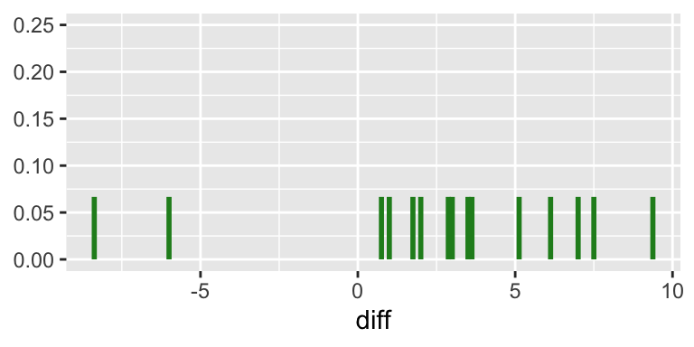

```r
ggplot(data.frame(ZeaMays, y = 1/15),
       aes(x = diff, ymax = 1/15, ymin = 0)) +
  geom_linerange(size=1, col= "forestgreen") +
  ylim(0, 0.25)
```

We use simulations as described above to approximate the sampling distribution for the median of the Zea Mays differences:

Draw $B=10,000$ samples of size 15 from the 15 values (each their own little component in the 15 part mixture). Then compute the 10,000 medians of each of these sets of 15 values and look at their distribution:

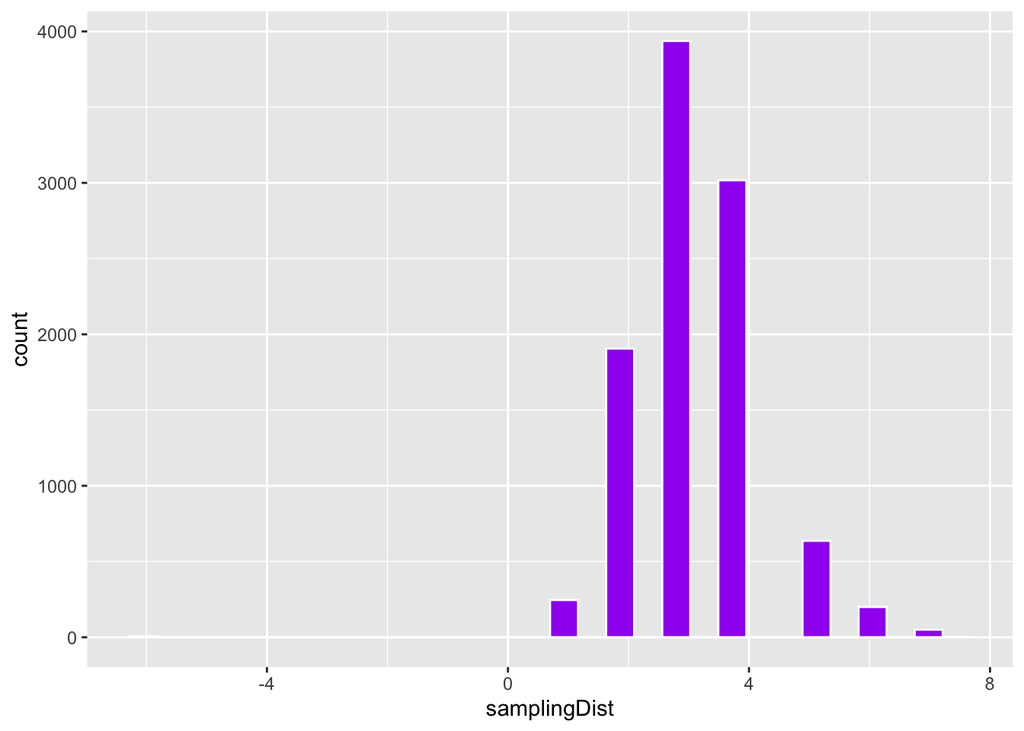

```r
set.seed(1)
B = 10000
diff = ZeaMays$diff
samplesIdx = replicate(B, sample(15, 15, replace = T))
samplingDist = apply(samplesIdx, 2, function(x) {return(median(diff[x]))})

ggplot(data.frame(samplingDist),aes(x = samplingDist)) +
  geom_histogram(bins=30, col = "white", fill = "purple")
```

Can you use `geom_vline` to visualize the median of the full (non-simulated) `ZeaMays$diff` dataset? Where does it lie compared to the medians calculated via bootstrapping?

**Question 4**:Give the upper end of a centered 95% confidence interval for the median based on the above bootstrap sample. Tip: Use the `quantile` function.

```r
# TODO
```

## Infinite mixtures

In our finite mixture examples, we generated observations as follows: choose the parameter $\theta$ to be one of two values $\lambda_1, \lambda_2$ at random (e.g. by flipping a coin), then draw an observation from a parametric distribution with parameter $\theta$ equal to either $\lambda_1$ or $\lambda_2$ depending on the outcome of the coin flip.

It turns, that this procedure is easily generalizable. Instead of having the parameter $\theta$ assume one of finately many possible values, e.g. $\theta \in \{\lambda_1, \lambda_2, dots, \lambda_K\}$, we can model $\theta$ itself as a random variable from a continuous distribution (and hence there will be infinitely many choices for $\theta$).

Let us quickly remark that we already saw the Gamma distribution in Lab 1, where it appears as the result of adding exponential random variables. To get more insight, we also note that the Gamma distribution is always continuous and positive-valued.

While the density of the exponential variable has its maximum at zero and then simply decreases towards 0 as the value goes to infinity, the density of the gamma distribution has its maximum at some finite value. Let’s explore this distribution by simulation examples with various parameters.

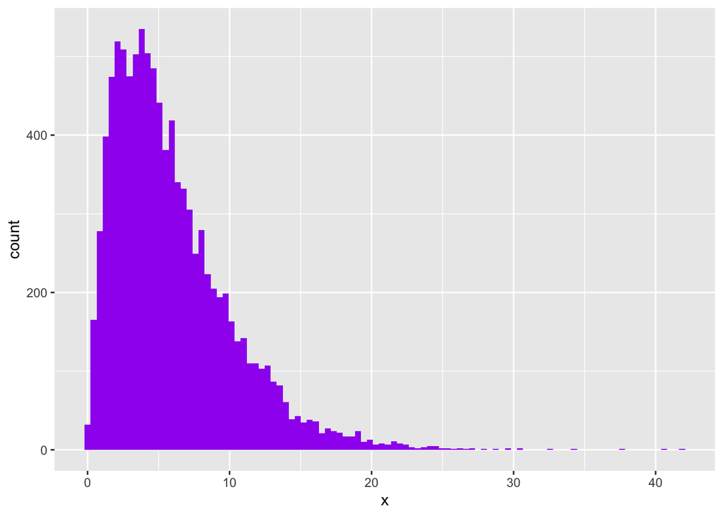

```r
ggplot(data.frame(x = rgamma(10000, shape = 2, rate = 1/3)),
   aes(x = x)) + geom_histogram(bins = 100, fill= "purple")
```

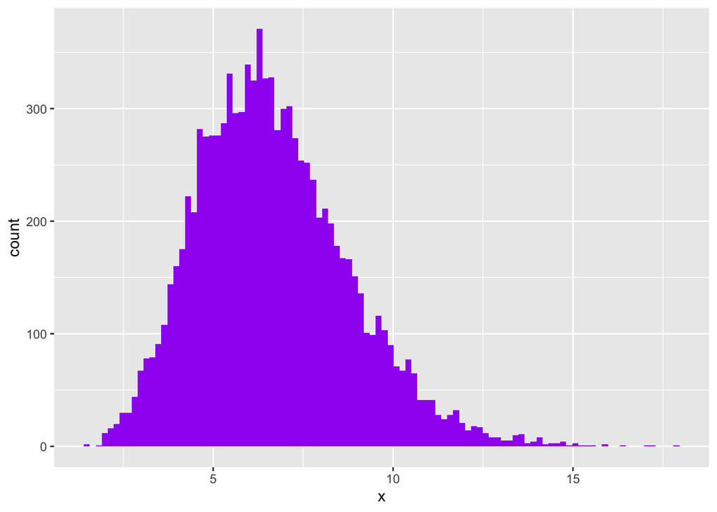

```r
ggplot(data.frame(x = rgamma(10000, shape = 10, rate = 3/2)),
   aes(x = x)) + geom_histogram(bins = 100, fill= "purple")
```

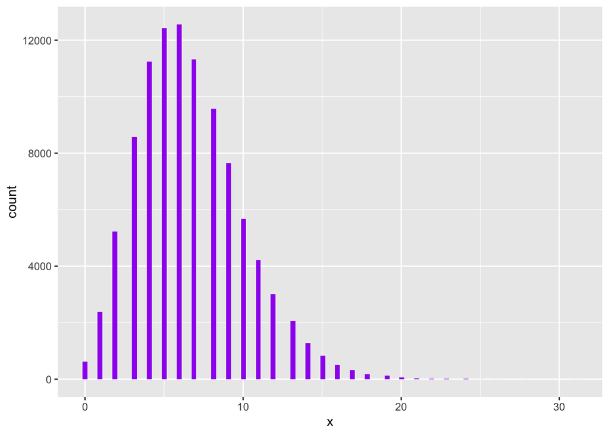

```r
lambda = rgamma(100000, shape = 10, rate = 3/2)
gp = rpois(length(lambda), lambda = lambda)

ggplot(data.frame(x = gp), aes(x = x)) +
  geom_histogram(bins = 100, fill= "purple")
```

We point out that the Gamma-Poisson distribution is also often called the Negative-Binomial distribution. They are the same (can only differ by the choice of parametrization). In R you can directly generate samples from this distribution using `rnbinom` (and of course you have access to `dnbinom` etc).

## Variance Stabilization

A key issue we need to control when we analyse experimental data is how much variability there is between repeated measurements of the same underlying true value. This will determine whether and how well we can see any true differences, due to, e.g., atreatment with a drug. Data that arise through the type of hierarchical models we have studied in this chapter often turn out to have very heterogenous variances, and this can be a challenge. We'll see how in such cases variance stabilizing transformations can help.

Let's start with a series of Poisson variables with rates $\lambda$:

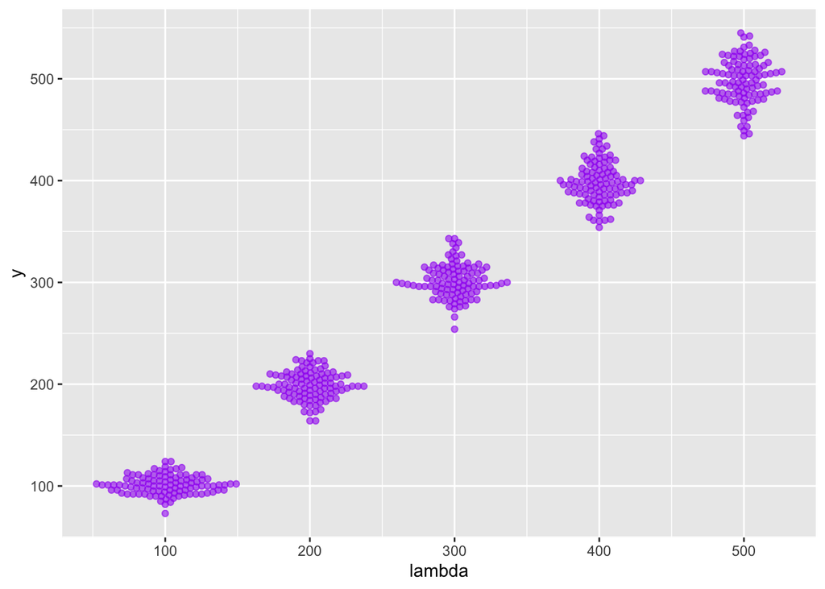

```r
lambdas = seq(100, 500, by = 100)

simdat = lapply(lambdas, function(l)
  data.frame(y = rpois(n = 100, lambda = l), lambda = l)) %>%
  bind_rows()

library("ggbeeswarm")
ggplot(simdat, aes( x=lambda, y=y)) +
  geom_beeswarm(alpha = 0.6, color="purple")
```

Clearly, the variance of the random numbers, differs at different levels of $\lambda$ ($\lambda$ the parameter of a Poisson distribution is also equal to its mean $\mu$).

In fact, we can show mathematically, that for Poisson variables there is a mean-variance relationship of the form $V(\mu)=\mu$, i.e. the variance is equal to the mean!

But we can approximately stabilize the variances (make it constant across different levels of the mean) by transforming the $y$ variable with a square root function. This is often referd to as variance stabilizing transformation (VST). Note that, the square root works for Poisson variables, but it might not be appropriate for other functions. Thus, VST's are distribution specific.

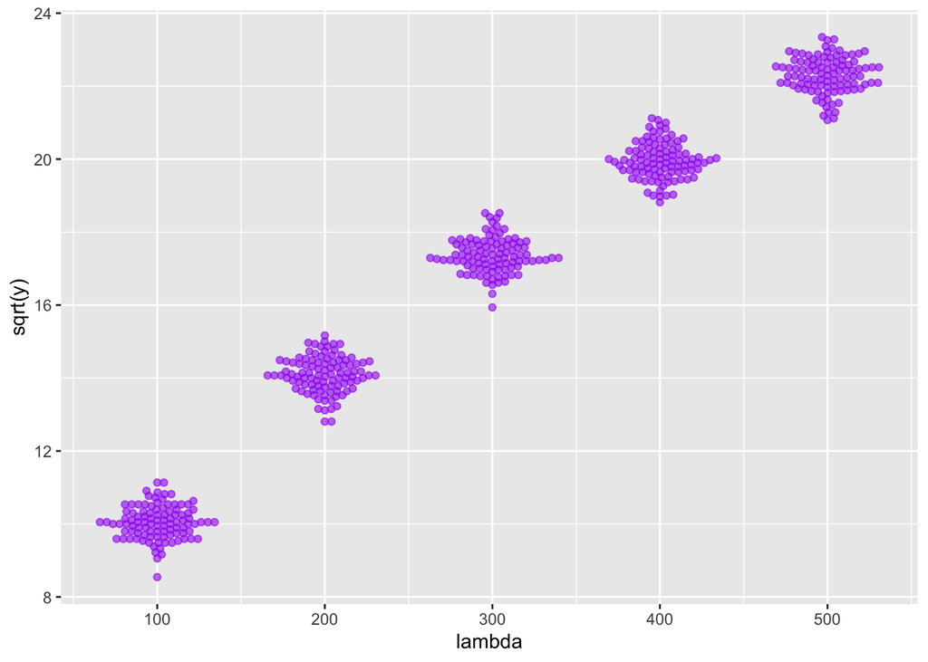

```r
ggplot(simdat, aes( x=lambda, y=sqrt(y))) +
  geom_beeswarm(alpha = 0.6, color="purple")
```

If the square root transformation is applied to each of the variables, then the transformed variables will have approximately constant variance (actually if we take the transformation $x \longrightarrow 2\sqrt{x}$ we obtain a standard deviation approximately equal to 1).

```r
summarise(group_by(simdat, lambda), sd(y), sd(2*sqrt(y)))
```

```
## # A tibble: 5 x 3
##   lambda `sd(y)` `sd(2 * sqrt(y))`
##    <dbl>   <dbl>             <dbl>
## 1    100    9.18             0.915
## 2    200   13.7              0.976
## 3    300   16.4              0.945
## 4    400   19.9              0.993
## 5    500   21.9              0.984
```

Similar strategies have been developed also for messy real world datasets, such as Microarrays and RNA-Seq datasets and have been essential to their statistical analysis.

For another example, let us revisit the negative binomial (Gamma-Poisson distribution), here the mean variance relationship takes the form $V(\mu) = \mu + c\mu^2$, so the factor $c\mu^2$ is additional variability compared to the poisson. Let us explore this by simulation as well. We generate Gamma-Poisson variables and plot the 95% confidence intervals around the mean.

```r
muvalues = 2^seq(0, 10, by = 1)
simgp = lapply(muvalues, function(mu) {
  u = rnbinom(n = 1e4, mu = mu, size = 4)
  data.frame(mean = mean(u), sd = sd(u),
         lower = quantile(u, 0.025),
         upper = quantile(u, 0.975),
         mu = mu)
  } ) %>% bind_rows
head(as.data.frame(simgp), 2)
```

```
##            mean       sd lower upper mu
## 2.5%...1 1.0104 1.135791     0     4  1
## 2.5%...2 2.0281 1.744195     0     6  2
```

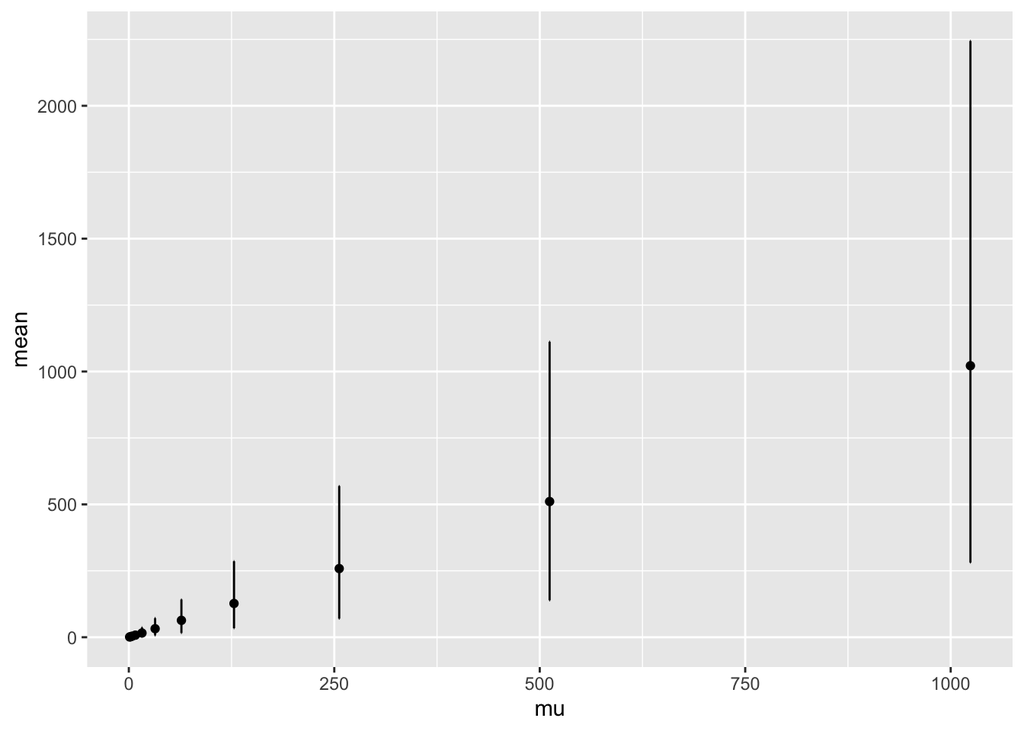

```r
ggplot(simgp, aes(x = mu, y = mean, ymin = lower, ymax = upper)) +
  geom_point() + geom_errorbar()
```

Repeat the above with an equidistant grid of `muvalues` and the plot the Variance versus the Mean. Do you observe the mean-variance relationship of the form $V(\mu) = \mu + c\mu^2$?

See the book about how to variance stabilize data coming from a Negative Binomial distribution!

## Intro to RNA-Seq

The ideas we have presented in this lab were quintessential for the development of methods (such as DESeq2, which we will cover tomorrow) able to handle high-throughput count data.

Such datasets often come with a low number of replicates, which means that it is important to have a parametric model. On the other hand, assuming the simplest model for count data, i.e. Poisson, is too simplistic and does not account for additional biological variability beyond Poisson noise. Luckily, we can capture this additional variability to really good approximation by employing the Gamma-Poisson distribution, which as we saw above is an infinite mixture of Poisson distributions. Moreover, the Gamma-Poisson distribution enables the development of a particular variance stabilization strategy (which is somewhat more complicated than the square root transformation for Poisson counts, but not a lot!).

Let us see the above in action with a RNASeq dataset, which is from an experiment on Drosophila melanogaster cell cultures that investigated the effect of RNAi knock-down of the splicing factor pasilla (Brooks et al. 2011) on the cells’ transcriptome. There were two experimental conditions, termed untreated and treated in the header of the count table that we loaded. They correspond to negative control and to siRNA against pasilla.

Let us first load the dataset:

```r
fn = system.file("extdata", "pasilla_gene_counts.tsv",
                 package = "pasilla", mustWork = TRUE)
counts = as.matrix(read.csv(fn, sep = "\t", row.names = "gene_id"))
dim(counts)
```

```
## [1] 14599     7
```

Note that the `counts` matrix consists of the counts for each of 14599 genes as measured in 7 different samples.

Before proceeding we note that a difficulty of working with count datasets is that there are variations in the total number of reads in each sample. The step below, which will be explained in more detail next week, normalizes the counts, hence "fixing" the issue of unequal number of reads (essentially we multiply the counts of all genes coming from a given sample with an appropriate scalar size factor).

```r
head(counts)
```

```
##             untreated1 untreated2 untreated3 untreated4 treated1 treated2
## FBgn0000003          0          0          0          0        0        0
## FBgn0000008         92        161         76         70      140       88
## FBgn0000014          5          1          0          0        4        0
## FBgn0000015          0          2          1          2        1        0
## FBgn0000017       4664       8714       3564       3150     6205     3072
## FBgn0000018        583        761        245        310      722      299
##             treated3
## FBgn0000003        1
## FBgn0000008       70
## FBgn0000014        0
## FBgn0000015        0
## FBgn0000017     3334
## FBgn0000018      308
```

```r
sf = estimateSizeFactorsForMatrix(counts)
ncounts  = counts / matrix(sf, byrow = TRUE, ncol = ncol(counts), nrow = nrow(counts))
head(ncounts)
```

```
##              untreated1   untreated2  untreated3  untreated4     treated1
## FBgn0000003    0.000000    0.0000000    0.000000    0.000000    0.0000000
## FBgn0000008   80.824908   89.7936241  117.004615   93.123591   85.5968034
## FBgn0000014    4.392658    0.5577244    0.000000    0.000000    2.4456230
## FBgn0000015    0.000000    1.1154487    1.539534    2.660674    0.6114057
## FBgn0000017 4097.471407 4860.0101913 5486.900612 4190.561607 3793.7726082
## FBgn0000018  512.183926  424.4282483  377.185929  412.404476  441.4349433
##              treated2    treated3
## FBgn0000003    0.0000    1.200981
## FBgn0000008  115.5963   84.068670
## FBgn0000014    0.0000    0.000000
## FBgn0000015    0.0000    0.000000
## FBgn0000017 4035.3632 4004.070676
## FBgn0000018  392.7648  369.902150
```

```r
# only untreated samples
uncounts = ncounts[, grep("^untreated", colnames(ncounts)), drop = FALSE]
head(uncounts)
```

```
##              untreated1   untreated2  untreated3  untreated4
## FBgn0000003    0.000000    0.0000000    0.000000    0.000000
## FBgn0000008   80.824908   89.7936241  117.004615   93.123591
## FBgn0000014    4.392658    0.5577244    0.000000    0.000000
## FBgn0000015    0.000000    1.1154487    1.539534    2.660674
## FBgn0000017 4097.471407 4860.0101913 5486.900612 4190.561607
## FBgn0000018  512.183926  424.4282483  377.185929  412.404476
```

Now that we normalized the counts, let us explore the mean-variance relationship:

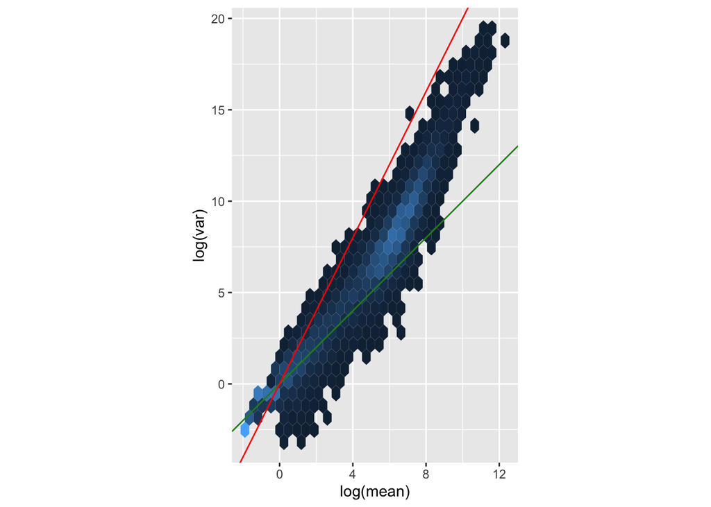

```r
ggplot(data.frame( mean = rowMeans(uncounts), var  = rowVars( uncounts)),
       aes(x = log(mean), y = log(var))) +
  geom_hex() +
  geom_abline(slope = 1:2, color = c("forestgreen", "red")) +
  coord_fixed() + theme(legend.position = "none")
```

Here again we can clearly see the mean-variance relationship which we theoretically expect for the gamma-Poisson distribution!

Note that, the green line (slope 1) is what we expect if the variance equals the mean as is the case for a Poisson-distributed random variable. We see that this approximately fits the data in the lower range. The red line (slope 2) corresponds to the quadratic mean-variance relationship $v=m^2$.